# Project Proposal

Rohit Yadav

07/12/2021

**Necessary Code**

### **Introduction**

The dataset I used in this project is about heart disease. Depending on various components we are Analyzing weather a person has chances of heart failure or not. This dataset has 12 variables including categorical and numerical. The dataset is downloaded from Kaggle, you can also find the link to this dataset and explanation of every variable present in dataset below.

**Link to the dataset:** [*Heart-Failure-Prediction*](https://www.kaggle.com/fedesoriano/heart-failure-prediction?select=heart.csv)

**Different type of variables in dataset:**

**Age:** It is a Continuous (Numerical) variable contains age of person.

**Sex:** It is a Nominal (Categorical) variable contains gender of person.

**ChestPainType:** It is a Nominal (Categorical) variable. It contains type of pain person have in chest. There are four types: ASY, ATA, NAP, TA

**RestingBP:** It is a Discrete (Numerical) variable contains resting blood pressure levels.

**Cholesterol:** It is a Discrete (Numerical) variable contains resting blood pressure levels.

**FastingBS:** It is a Binary (Categorical) variable contains information regarding fasting blood sugar.

**RestingECG:** It is a Nominal (Categorical) variable contains resting electrocardiogram value.

**MaxHR:** It is a Discrete (Numerical) variable contains value of maximum heart rate.

**ExerciseAngina:** It is a Binary (Categorical) variable. It is also known as stable angina which is triggered by physical activity When you climb stairs, exercise, or walk, your heart demands more blood.

**Oldpeak:** It is a Discrete (Numerical) variable. Oldpeak is a component used in predicting heart disease. It is St depression in resting state after exercise.

**ST_Slope:** It is a Nominal (Categorical) variable. This is the slope of peak exercise ST segment which is than compared with the heart ECG report.

**HeartDisease:** It is a Binary (Categorical) variable. It contains weather a person has a heart disease or not based on the different components that we have discussed above.

**General research question:** Among the 12 different variables that we have in our data set, do analysis on each variable or group of variables, and identify what components or variables are affecting the result?

#### **Data Analysis Plan**

**Outcome & Usage of the analysis:** After analyzing this data set, we will find that what are the different independent variable or set of independent variables that are responsible in affecting the dependent variable most.

**Will be Analyzing these dependent variables:-**  
Age, Sex, ChestPainType, RestingBP, Cholesterol, FastingBS, RestingECG, MaxHR, ExerciseAngina, Oldpeak, ST_Slope.

**Corresponding to this dependent variable:-**  
HeartDisease

**Will also analyze multiple variables in a single plot.**  
For example : Analyzing RestingBP, Cholesterol, ChestPainType w.r.t HeartDisease  
Analyzing MaxHR, Oldpeak, RestingECG, ST_Slope w.r.t HeartDisease

**Summary Statistics**

```
##       Age            Sex            ChestPainType        RestingBP
##  Min.   :28.00   Length:918         Length:918         Min.   :  0.0
##  1st Qu.:47.00   Class :character   Class :character   1st Qu.:120.0
##  Median :54.00   Mode  :character   Mode  :character   Median :130.0
##  Mean   :53.51                                         Mean   :132.4
##  3rd Qu.:60.00                                         3rd Qu.:140.0
##  Max.   :77.00                                         Max.   :200.0
##   Cholesterol     FastingBS          RestingECG            MaxHR
##  Min.   :  0.0   Length:918         Length:918         Min.   : 60.0
##  1st Qu.:173.2   Class :character   Class :character   1st Qu.:120.0
##  Median :223.0   Mode  :character   Mode  :character   Median :138.0
##  Mean   :198.8                                         Mean   :136.8
##  3rd Qu.:267.0                                         3rd Qu.:156.0
##  Max.   :603.0                                         Max.   :202.0
##  ExerciseAngina        Oldpeak          ST_Slope         HeartDisease
##  Length:918         Min.   :-2.6000   Length:918         Length:918
##  Class :character   1st Qu.: 0.0000   Class :character   Class :character
##  Mode  :character   Median : 0.6000   Mode  :character   Mode  :character
##                     Mean   : 0.8874
##                     3rd Qu.: 1.5000
##                     Max.   : 6.2000
```

**Taking a look at dataset**

**Top Rows:**

```
## # A tibble: 6 x 12
##     Age Sex   ChestPainType RestingBP Cholesterol FastingBS RestingECG MaxHR
##   <dbl> <chr> <chr>             <dbl>       <dbl> <chr>     <chr>      <dbl>
## 1    40 M     ATA                 140         289 NO        Normal       172
## 2    49 F     NAP                 160         180 NO        Normal       156
## 3    37 M     ATA                 130         283 NO        ST            98
## 4    48 F     ASY                 138         214 NO        Normal       108
## 5    54 M     NAP                 150         195 NO        Normal       122
## 6    39 M     NAP                 120         339 NO        Normal       170
## # ... with 4 more variables: ExerciseAngina <chr>, Oldpeak <dbl>,
## #   ST_Slope <chr>, HeartDisease <chr>
```

**Bottom Rows:**

```
## # A tibble: 6 x 12
##     Age Sex   ChestPainType RestingBP Cholesterol FastingBS RestingECG MaxHR
##   <dbl> <chr> <chr>             <dbl>       <dbl> <chr>     <chr>      <dbl>
## 1    57 F     ASY                 140         241 NO        Normal       123
## 2    45 M     TA                  110         264 NO        Normal       132
## 3    68 M     ASY                 144         193 YES       Normal       141
## 4    57 M     ASY                 130         131 NO        Normal       115
## 5    57 F     ATA                 130         236 NO        LVH          174
## 6    38 M     NAP                 138         175 NO        Normal       173
## # ... with 4 more variables: ExerciseAngina <chr>, Oldpeak <dbl>,
## #   ST_Slope <chr>, HeartDisease <chr>
```

Now, let’s check what are the different age groups where there are more than 50% of people who have heart disease, we will apply some data transformation using dplyr verbs to do this.

```
## # A tibble: 25 x 3
##      Age TotalPeople PercentHaveDisease
##    <dbl>       <int>              <dbl>
##  1    75           3                 67
##  2    74           7                 71
##  3    72           4                 75
##  4    70           7                 86
##  5    69          13                 77
##  6    68          10                 60
##  7    67          15                 80
##  8    66          13                 54
##  9    65          21                 71
## 10    64          22                 68
## # ... with 15 more rows
```

Here we can see the total number of people corresponding to that age group and the percentage of people have heart disease in that age group. I have filtered the age group where the percent of people having heart disease is greater that 50%.

**Let’s understand this more clearly by visualization.**

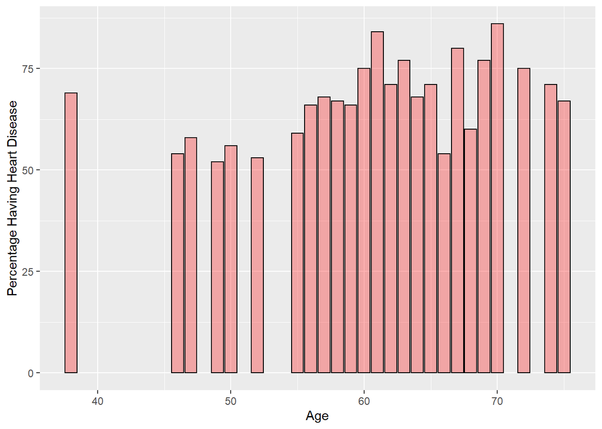

**Analyzing Gender with heart disease.**  
In below plot we can see that males are more likely to have heart disease that female.

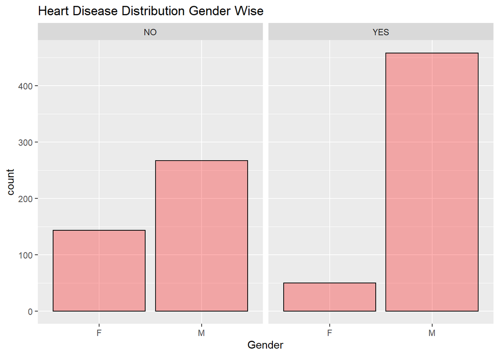

Minimum age now in dataset.

```
## [1] 38
```

Maximum age now in dataset.

```
## [1] 75
```

**Distribution of Cholesterol**  
We can see in the below plot that there are some outliers above 400.

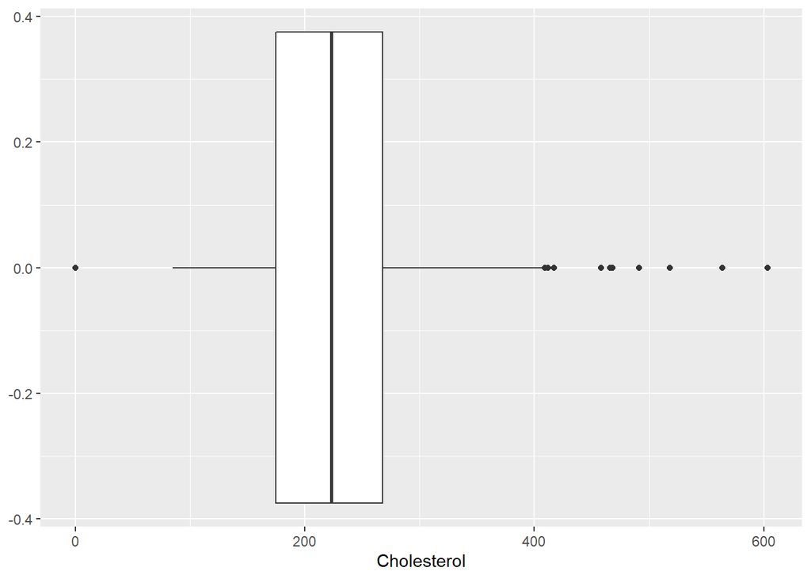

Now let’s remove the outliers that are present cholesterol variable,

```
##   0%  25%  50%  75% 100%
##    0  175  223  268  603
```

```
## [1] 407.5
```

```
## [1] 35.5
```

**Removing the Outliers from data set**

```r
heartnew<-heartnew%>%filter(Cholesterol<407.5 & Cholesterol>35.5)
```